# 120 Lec 5

Tim Hagemeister

09 September, 2019

## Populations, Samples, and Inference

-**Population**: All individuals of interest. (Too big!) -**Sample**: A subset that we can actually work with. -**Statistical Inference**: the process of making conclusions about populations given the result of our sample data -**Note**: a statistic is a numerical summary of a sample. a parameter is a numerical summery of the population. - we hope to say something smart about paramerters *based on* statistics. -**Examples of statistics**: -mean, meadian, stedv, iqr, mode, proportion -**Robust Statistics**: A statistic is **robust** if it’s not not affected by skew/outliers. -Example: mpg displacement

```r
mpg %>% head
```

```
## # A tibble: 6 x 11
##   manufacturer model displ  year   cyl trans  drv     cty   hwy fl    class
##   <chr>        <chr> <dbl> <int> <int> <chr>  <chr> <int> <int> <chr> <chr>
## 1 audi         a4      1.8  1999     4 auto(… f        18    29 p     comp…
## 2 audi         a4      1.8  1999     4 manua… f        21    29 p     comp…
## 3 audi         a4      2    2008     4 manua… f        20    31 p     comp…
## 4 audi         a4      2    2008     4 auto(… f        21    30 p     comp…
## 5 audi         a4      2.8  1999     6 auto(… f        16    26 p     comp…
## 6 audi         a4      2.8  1999     6 manua… f        18    26 p     comp…
```

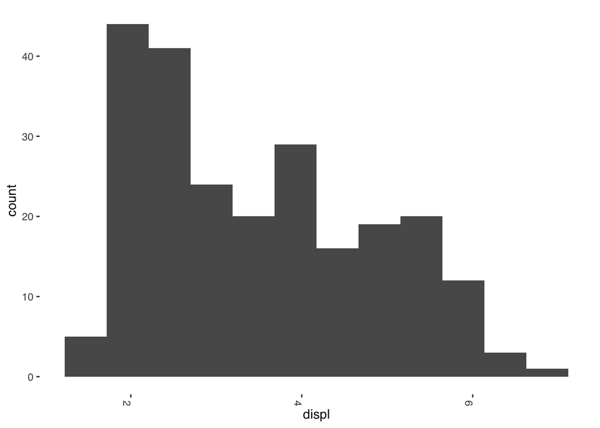

```r
ggplot(mpg, aes(x=displ))+
  geom_histogram(bins = 12)
```

```r
summary(mpg$displ)
```

```
##    Min. 1st Qu.  Median    Mean 3rd Qu.    Max.
##   1.600   2.400   3.300   3.472   4.600   7.000
```

**Observation**: clear right skew, now how does this effect the center

**Commentary**: we see here that the mean is not robust. it is being affected by the right skew of the distribution.

**Note**: mean always gets oulled with skew, but meadian is not affected.

**Another example**: IQR (middle 50% doesnt care about extreems) and stdevv (gets messed up by outliers)

## Observational Studies vs Experiments

Key difference: In an experiment, we apply a treatment.

Think: A survey is always an *observational study*

A medical trial is an *experiment*

important note: observational studies can never establish **causation** only **correlation**, correlation does not imply causation

Ex: 1.22ab

**explanitory variable**: Stress

**response variable**: Muscle cramps

**Confounding variables**: are other things that could have caused other things going on, coffee and sleep make it hard to see if stress is really the important factor.

## Sampling Problems

We need to be sure our sample is “good”!

“Representative” or not?

In order to be useful, we need some assurance that the sample is “similar to” the population.

In mathese: Hope our statistics are close to the true population parameter.

### Bias, Nonresponse Bias, and Confounding Variables

- **Sample Bias**: Some indivuals (“cases”) more likely to be observed.
- **Nonresponse Bias**: Some individuals excluded from sample selection process.
- **Confounding Variables**: Other variables that might affect response variable.

Ex: 1,22c, 1.24 and 1.26

- 1.24 = phone book could introduce non response bias: not everyone is listed, they would never have been sampled, we would not get a represnetative sample
- 1.26 = -nonresponse bias: families with zero children are never sampled nor students with older kids, -Sample bias: families with many children are more likely to be sampled! -could bias measure of fmaily size to be bigger

## Sampling Strategies

### Simple Random Sample (SRS)

- Every member of the population is **equally likely to be sampled**. -Best kind!

### Stratified

- Break into similar “strata”, SRS within each strata.
- Ensure all groups represented.
- Example strata: gender, age, income, education, etc.

### Clustered

- Break into “clusters”, randomloy select which clusters used, sample everyone in chosen clusters.
- Useful for sample over large geographic area
- Example clusters: city block, county

### Multistage

First cluster, then SRS within selected clusters. Nice, but expensive.

Ex: 1.19, 1.23